# In-Store Mobile Phone Use and Customer Shopping Behavior

Jarrod Griffin

6/23/2025

### In‑Store Mobile Phone Use & Consumer Shopping Behavior: Evidence from the Field (Grewal *et al.*, 2018)

> Grewal, Dhruv, Carl-Philip Ahlbom, Lauren Beitelspacher, Stephanie M. Noble, and Jens Nordfält (2018), “**In-Store Mobile Phone Use and Customer Shopping Behavior: Evidence from the Field,**” *Journal of Marketing*, 82 (4), 102–126.

## Presentation Road‑Map

1. Introduction & Motivation
2. Theory & Hypotheses
3. **Study 1** — Method & Results
4. **Study 2** — Method & Results
5. Integrated Discussion & Managerial Implications
6. Limitations & Future Research
7. Class Discussion Prompts

## Introduction

### Problem / Motivation

- **Mobile ubiquity:** 95 % of U.S. consumers own a mobile phone and 77 % a smartphone (Pew Research Center 2018); penetration ≈ 65 % worldwide and 84 % in Europe (GSMA 2017).
- **Screen time:** Adults log ~6 h/day of digital media use; nearly half is on mobile devices (eMarketer 2017).
- **In‑store paradox:** Phones can create *“mobile blinders”* distracting shoppers from impulse displays and lowering recall (Bellini & Aiolfi 2017; Atalay, Bodur, & Bressoud 2017). Yet they also enable richer searches and mobile coupon redemption (Burke 2002; Hui et al. 2013).
- **Retailer dilemma:** Discourage phone use to protect impulse sales **or** embrace it to enhance engagement?
- **Research gap:** No comprehensive field evidence on how ordinary in‑store phone use affects **overall sales** and shopper satisfaction.

### Research Objectives

- *RO1:* Does mobile phone use in stores influence purchases?
- *RO2:* Identify **behavioral mechanisms** (time, visual attention, path diversion) responsible for this effect.
- *RO3:* What are the boundary conditions for the mobile-phone effect?
- *RO4:* Does distraction due to mobile phone use decrease or increase customer satisfaction with the shopping experience?

# Hypotheses

## Time Path — Prior Evidence

- **Attention diversion slows tasks:** When cognitive resources shift to phones, shoppers neglect lists/goals, prolonging trips (Block & Morwitz 1999; Inman, Winer, & Ferraro 2009).
- **Longer dwell → larger baskets:** Empirical store‑tracking work links minutes in aisle to higher spend (Sorensen 2003).

### **Hypothesis 1**

> **H1a.** Mobile phone use increases **total time** spent in the store.  
> **H1b.** More time in store increases **purchases**.

## Shelf‑Attention Path — Prior Evidence

- **Pause = extra visual sweep:** Phone‑induced stops grant shoppers seconds to scan nearby products (Atalay, Bodur, & Bressoud 2017).
- Visual‑attention work shows even micro‑fixations raise product awareness (Anstis 1998; Pieters & Wedel 2012).

### **Hypothesis 2**

> **H2a.** Mobile phone use increases **shelf attention**.  
> **H2b.** Greater shelf attention increases **purchases**.

## Loop‑Diversion Path — Prior Evidence

- Shoppers follow spatial scripts around the perimeter; distraction prompts deviations/back‑tracking (Bower, Black, & Turner 1979).
- Deviations expose consumers to otherwise unseen SKUs, boosting unplanned buys (Hui et al. 2013).

### **Hypothesis 3**

> **H3a.** Mobile phone use increases **loop diversion**.  
> **H3b.** Greater loop diversion increases **purchases**.

## Mediation Test — Integrating the Paths

- **Limited‑capacity theory** (Repovš & Baddeley 2006) predicts that time, attention, and path shifts collectively transmit distraction effects to spending.

### **Hypothesis 4**

> **H4.** **Time in store, shelf attention,** and **loop diversion** jointly mediate the positive relationship between phone use and purchases.

# Study 1 — Naturalistic Field Study

### Study Design

- **Context:** Real‑life grocery shopping trips in four suburban Stockholm supermarkets (~36 140 ft² each).
- **Method:** **Eye‑tracking field study** — portable Tobii Pro glasses record visual field & gaze.
- **Purpose:** Capture *natural* shopper behavior; maximize ecological validity vs. lab scenarios.

### Sampling & Data Collection

- **Recruitment:** Research staff at store entrances (Mon–Sun, 09:00–17:00).
- Intercept every passer‑by; offer coupon incentive; no mention of phone focus.
- **Initial recruits:** 393 shoppers → 359 with usable video → **294 final** (completed exit survey).

### Procedure

1. Consent & fit Tobii glasses.
2. Shopper completes trip *“as usual.”*
3. Staff collects glasses & receipt at checkout.
4. Exit survey: demographics + satisfaction.
5. Coders transform 90 h of video into gaze & movement metrics.

### Sample Characteristics

- **n = 294** | Age 18‑73 (M = 41.5).
- **Gender:** 39.5 % female.
- No demographic differences across stores or phone‑use groups.

### Measures

| Role | Variable | Operationalization |
| --- | --- | --- |
| **IV** | Mobile phone use | Binary (0 = none, 1 = used; duration captured) |
| **Mediators** | Total time in store | Minutes from entry to checkout |
|  | Shelf attention | Count of analytical fixations on products/price tags |
|  | Loop diversion | Back‑tracks off natural customer loop (#) |
| **DV** | Purchases | Basket value (SEK) and item count |
| **Control** | Satisfaction | 1‑7 overall visit rating |

### Mediation Model

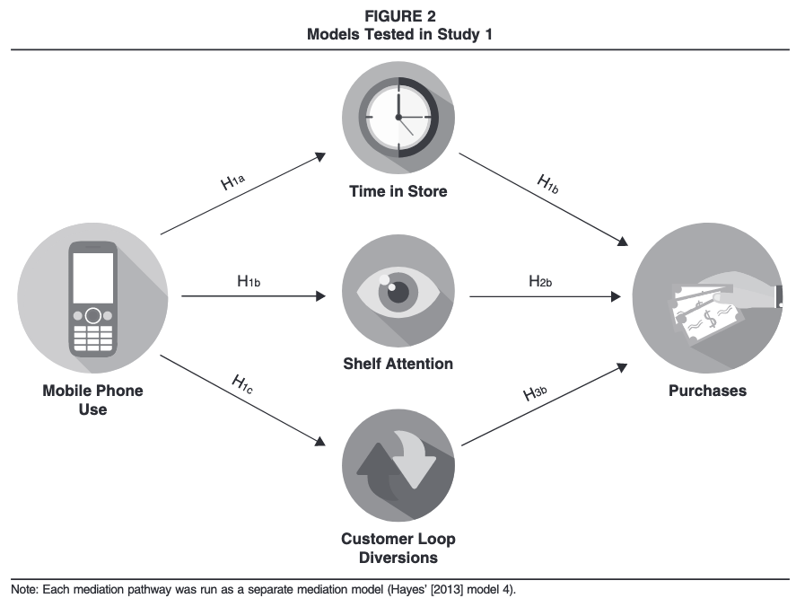

Models Tested in Study 1

### Study 1 Results (Key Paths)

- Mobile users spent **+4.6 min** in store *(p < .001)*.
- Shelf fixations **+17 %** *(p = .02)*.
- Loop diversions **+0.97** *(p < .001)*.
- Basket value **+120 SEK** (~$14) *(p = .007)*.
- Indirect effects via all three mediators significant.

## Study 2 — Field Experiment

### Purpose & Design

- **Goal 1:** Replicate Study 1 findings with fresh sample.
- **Goal 2:** Eliminate **self‑selection bias** via **random assignment** to phone‑use vs no‑use condition.
- **Goal 3:** Directly measure **distraction** to test limited‑attention theory (4‑item, α =.90).

### Sampling & Random Assignment

- **Setting:** Two suburban grocery stores (same chain).
- **Recruitment:** Every **5th** passer‑by at a predefined entrance point; scratch‑off lottery ticket incentive.
- **Eligibility:** Must carry a mobile phone (4 shoppers excluded).
- **Sample:** 121 recruited → 117 usable (24 h of eye‑tracking video).
- **Randomization:** Assigned to **Phone‑Allowed** (n = 53) or **Phone‑Prohibited** (n = 64) groups.

### Procedure

1. Consent, demographic pre‑survey.
2. Fit Tobii Pro glasses.
3. **Condition instructions:**
   - *Use group:* “Please use your smartphone as you normally would—email, browse, play, etc.”
   - *No‑use group:* “Please refrain from **all** phone use during this trip.”
4. Shopper completes trip.
5. Collect glasses & receipt.
6. Post‑trip survey: **distraction scale**, satisfaction, demographics.

### Sample Characteristics

- **n = 117** | Age 19‑80 (M = 42.9).
- **Gender:** 52.1 % female.
- No age, gender, or household‑size differences across conditions.

### Measures

| Role | Variable | Operationalization |
| --- | --- | --- |
| **IV** | Phone condition | Random assignment; compliance 97 % |
| **Mediator 1** | Distraction | 4‑item scale (e.g., “I felt distracted…”) |
| **Mediator 2‑4** | Time in store / Shelf attention / Loop diversion | Same coding as Study 1 |
| **DV** | Purchases | Basket value (SEK) + item count |
| **Controls** | Satisfaction (trip & service) | 1‑5 scales |

### Manipulation Check & Compliance

- **Non‑use group:** 96.9 % obeyed (2 urgent calls).
- **Use group:** 96.2 % used phones (~0.74 min; 4.8 % of trip).
- Randomization + high compliance ⇒ strong internal validity.

### Analysis Model

- **Serial mediation:** Phone condition → **Distraction** → (Time | Fixations | Diversion) → Purchases.
- PROCESS Models 4 & 6; 100 000 bootstrap iterations.

### Key Results

| Path | β / Diff | p / CI | Supported |
| --- | --- | --- | --- |
| Phone → Distraction | +0.85 | <.001 | ✔︎ |
| Phone → Time | +4.45 min | .03 | ✔︎ (H1a) |
| Phone → Fixations | +25.84 | .001 | ✔︎ (H2a) |
| Phone → Diversion | +0.28 | .07† | marginal |
| Mediations (H4a–c) | Indirect CIs exclude 0 | see text | ✔︎ / † |
| Purchases diff | +129 SEK | .10 | marginal but positive |

*Note:* Age significantly moderates all three mediator paths; older shoppers show stronger effects.

## Results Summary by Hypothesis

| Hypothesis | Study 1 | Study 2 | Verdict |
| --- | --- | --- | --- |
| **H1a** Time ↑ | **✔︎** +4.6 min *(p<.001)* | **✔︎** +4.45 min *(p=.03)* | Supported |
| **H1b** Time → Spend | **✔︎** β = 21.76 *(p<.001)* | **✔︎** β = 31.45 *(p<.001)* | Supported |
| **H2a** Fixations ↑ | **✔︎** +17 % *(p=.02)* | **✔︎** +25.84 *(p=.001)* | Supported |
| **H2b** Fixations → Spend | **✔︎** β = 3.97 *(p<.001)* | **✔︎** β = 7.13 *(p<.001)* | Supported |
| **H3a** Diversion ↑ | **✔︎** +0.97 *(p<.001)* | † +0.28 *(p=.07)* | Partial |
| **H3b** Diversion → Spend | **✔︎** β = 69.41 *(p<.001)* | **✔︎** β = 238.39 *(p<.001)* | Supported |
| **H4** Mediations | All three paths sig. | Two sig., diversion marginal | Largely Supported |

*(† = marginal, p < .10)*

## Theoretical Implications

- **Extends limited‑attention theory**: Shows distraction can *increase* rather than impair goal performance when the task is open‑ended (shopping).
- **Links micro‑level gaze to macro sales**: Connects eye‑tracking metrics to receipt data, bridging consumer psychology and retail analytics.
- **Aging & distraction**: Demonstrates greater susceptibility among shoppers > 32 yrs, enriching lifespan cognition research.
- **Generalizable distraction mechanism**: Parallel effects found for shopping‑with‑companions, hinting at a broader attentional conflict framework.

## Integrated Discussion

- **Distraction loop:** Phone use → cognitive split → linger, look, wander → **more items bought**.
- **Net‑positive experience:** Satisfaction unchanged (Study 1) or only marginally lower (Study 2); benefits outweigh any friction.
- **Spatial nuance:** Fresh‑food departments gain most; checkout losses confirm *mobile blinders* boundary.

## Managerial Implications

- Provide *free Wi‑Fi* & charging stations.
- Embed QR codes / digital shelf labels near high‑margin SKUs.
- Target **older shoppers** with phone‑friendly services (voice search).
- Reframe showrooming: in‑store phone use can **lift** spend.

## Limitations & Future Research

- Grocery context; test **department stores** & **electronics**.
- Manual coding limits eye‑tracking granularity.
- Explore *content* of phone use (e.g., social vs price‑check).
- Investigate motionless contexts (checkout, deli counter).

## Class Discussion Prompts

1. Should retailers ever **limit** phone use? Why / why not?
2. How might **AI partner apps** evolve these dynamics?
3. Where could *“bad friction”* still exist in this study’s design?

# Thank You

*Questions & Comments?*

Download PDF